# usl_project_PartA

```python
import numpy as np
import pandas as pd
import matplotlib.pyplot as plt
import seaborn as sns

from sklearn.cluster import KMeans
from sklearn import metrics
from scipy.stats import zscore
from sklearn.model_selection import RandomizedSearchCV, GridSearchCV

from sklearn.svm import SVC
from sklearn.decomposition import PCA

import warnings
warnings.filterwarnings('ignore')
```

## 1. Data understanding and exploration

#### Q1 A Read the Data set “data_add_nik.csv” and print the shape of the dataset

```python
data = pd.read_csv('data_adidas_nike.csv')
data_bkp = data.copy()
```

```python
data.head() #reading first 5 rows in the dataset
```

|  | Product Name | Product ID | Listing Price | Sale Price | Discount | Brand | Rating | Reviews |
| --- | --- | --- | --- | --- | --- | --- | --- | --- |
| 0 | Women's adidas Originals NMD_Racer Primeknit S... | AH2430 | 14999 | 7499 | 50 | Adidas Adidas ORIGINALS | 4.8 | 41 |
| 1 | Women's adidas Originals Sleek Shoes | G27341 | 7599 | 3799 | 50 | Adidas ORIGINALS | 3.3 | 24 |
| 2 | Women's adidas Swim Puka Slippers | CM0081 | 999 | 599 | 40 | Adidas CORE / NEO | 2.6 | 37 |
| 3 | Women's adidas Sport Inspired Questar Ride Shoes | B44832 | 6999 | 3499 | 50 | Adidas CORE / NEO | 4.1 | 35 |
| 4 | Women's adidas Originals Taekwondo Shoes | D98205 | 7999 | 3999 | 50 | Adidas ORIGINALS | 3.5 | 72 |

```python
data.shape #printing shape of the data
```

```
(3268, 8)
```

```python
data.info() #information of the dtypes of the dataset
```

```
<class 'pandas.core.frame.DataFrame'>
RangeIndex: 3268 entries, 0 to 3267
Data columns (total 8 columns):
 #   Column         Non-Null Count  Dtype
---  ------         --------------  -----
 0   Product Name   3268 non-null   object
 1   Product ID     3268 non-null   object
 2   Listing Price  3268 non-null   int64
 3   Sale Price     3268 non-null   int64
 4   Discount       3268 non-null   int64
 5   Brand          3268 non-null   object
 6   Rating         3268 non-null   float64
 7   Reviews        3268 non-null   int64
dtypes: float64(1), int64(4), object(3)
memory usage: 204.4+ KB
```

#### Observations:

1. There are 3 categorical columns and 5 numeric columns.
2. There are no null values in any columns of the dataset.
3. Dataset seems to be clean.

#### Q1 C Check if there are any duplicate records in the dataset. If yes, drop them

```python
data.duplicated().sum()
```

```
88
```

```python
data.loc[(data.duplicated()==True)]
```

|  | Product Name | Product ID | Listing Price | Sale Price | Discount | Brand | Rating | Reviews |
| --- | --- | --- | --- | --- | --- | --- | --- | --- |
| 2792 | Nike Metcon 5 AMP | CD3395-006 | 0 | 11995 | 0 | Nike | 5.0 | 2 |
| 2861 | Nike Mercurial Vapor 13 Club Neymar Jr. TF | AT8000-104 | 0 | 5495 | 0 | Nike | 0.0 | 0 |
| 2862 | Nike Mercurial Vapor 13 Elite Neymar Jr. FG | AT7898-104 | 0 | 22995 | 0 | Nike | 0.0 | 0 |
| 2863 | Nike Mercurial Vapor 13 Academy Neymar Jr. TF | AT7995-104 | 0 | 7995 | 0 | Nike | 0.0 | 0 |
| 2864 | Nike Mercurial Vapor 13 Academy Neymar Jr. MG | AT7960-104 | 0 | 7995 | 0 | Nike | 0.0 | 0 |
| ... | ... | ... | ... | ... | ... | ... | ... | ... |
| 3258 | Nike ZoomX Vaporfly NEXT% | AO4568-600 | 0 | 19995 | 0 | Nike | 4.7 | 45 |
| 3259 | Nike Mercurial Vapor 13 Academy IC | AT7993-414 | 7495 | 5247 | 0 | Nike | 0.0 | 0 |
| 3261 | Kyrie 6 'Enlightenment' | BQ4630-500 | 10995 | 8797 | 0 | Nike | 4.4 | 10 |
| 3264 | Nike Phantom Venom Club IC | AO0578-717 | 4995 | 3497 | 0 | Nike | 0.0 | 0 |
| 3265 | Nike Mercurial Superfly 7 Academy TF | AT7978-414 | 8495 | 5947 | 0 | Nike | 5.0 | 1 |

88 rows × 8 columns

```python
data.loc[data['Product ID'] == 'AT7898-104'] #viewing the duplicated rows
```

|  | Product Name | Product ID | Listing Price | Sale Price | Discount | Brand | Rating | Reviews |
| --- | --- | --- | --- | --- | --- | --- | --- | --- |
| 2674 | Nike Mercurial Vapor 13 Elite Neymar Jr. FG | AT7898-104 | 0 | 22995 | 0 | Nike | 0.0 | 0 |
| 2862 | Nike Mercurial Vapor 13 Elite Neymar Jr. FG | AT7898-104 | 0 | 22995 | 0 | Nike | 0.0 | 0 |

##### After reviewing random selections from the duplicated data, it can be easily concluded that, these can be dropped.

```python
data = data.drop_duplicates() #dropping the duplicates
```

```python
data.duplicated().sum()
```

```
0
```

#### Q1 D Check the 5 points summary of the whole data and share your observations

```python
data.describe().T
```

|  | count | mean | std | min | 25% | 50% | 75% | max |
| --- | --- | --- | --- | --- | --- | --- | --- | --- |
| Listing Price | 3180.0 | 6992.707547 | 4677.133304 | 0.0 | 4599.0 | 5999.0 | 8999.0 | 29999.0 |
| Sale Price | 3180.0 | 6027.742767 | 4192.481308 | 449.0 | 2999.0 | 4599.0 | 7995.0 | 36500.0 |
| Discount | 3180.0 | 27.619497 | 22.492385 | 0.0 | 0.0 | 40.0 | 50.0 | 60.0 |
| Rating | 3180.0 | 3.266635 | 1.393592 | 0.0 | 2.6 | 3.5 | 4.4 | 5.0 |
| Reviews | 3180.0 | 41.529560 | 31.373989 | 0.0 | 12.0 | 39.0 | 69.0 | 223.0 |

#### Q2 A Check how many products have Listing_price ‘0’. Check it’s 5 points summary and share your insights.

```python
data[data['Listing Price']==0]['Product Name'].value_counts()
```

```
Product Name
Nike Air Max 90                    10
Nike Air Max 2090                   5
Nike Air Max 270 React              5
Nike Air VaporMax 360               5
Nike Air Max 97                     5
                                   ..
Nike Zoom Fly                       1
Nike Air Zoom Pegasus 35            1
KD13 EP                             1
Nike Air Monarch IV                 1
Nike Tiempo Legend 8 Academy TF     1
Name: count, Length: 261, dtype: int64
```

```python
data['Listing Price'].describe().T
```

```
count     3180.000000
mean      6992.707547
std       4677.133304
min          0.000000
25%       4599.000000
50%       5999.000000
75%       8999.000000
max      29999.000000
Name: Listing Price, dtype: float64
```

#### Observations

1. Count: There are 3,180 listings in total.
2. Mean (Average): The average listing price is approximately 6,992.71.
3. Standard Deviation: The prices vary significantly with a standard deviation of about 4,677.13.
4. Minimum: The minimum listing price is 0, indicating some products have a zero listing price.
5. 25th Percentile (Q1): 25% of the listings have a price less than or equal to 4,599.
6. Median (Q2/50th Percentile): The median price is 5,999, indicating that half of the listings are priced below this value and half above.
7. 75th Percentile (Q3): 75% of the listings have a price less than or equal to 8,999.
8. Maximum: The highest listing price in the dataset is 29,999.

#### Q2 B Records having Listing_price ‘0’, replace them with Sale_Price of that record

```python
data.loc[data['Listing Price'] == 0, 'Listing Price'] = data['Sale Price']
```

```python
data.loc[data['Listing Price']==0]
```

|  | Product Name | Product ID | Listing Price | Sale Price | Discount | Brand | Rating | Reviews |
| --- | --- | --- | --- | --- | --- | --- | --- | --- |

#### Q2 C Check and print feature-wise percentage of missing values present in the data and impute with the best suitable approach.

```python
data.isnull().mean() * 100
```

```
Product Name     0.0
Product ID       0.0
Listing Price    0.0
Sale Price       0.0
Discount         0.0
Brand            0.0
Rating           0.0
Reviews          0.0
dtype: float64
```

##### There are no missing values in any columns. Hence imputation is not needed.

#### Exploratory Data analysis

#### Q2 D Perform univariate analysis on the data and share your insights.

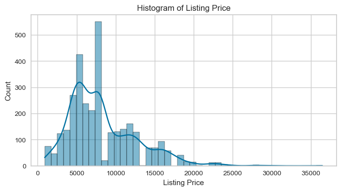

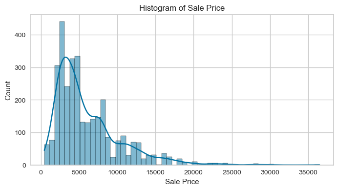

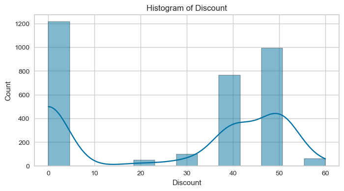

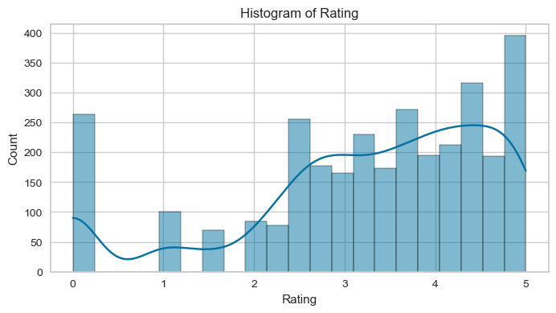

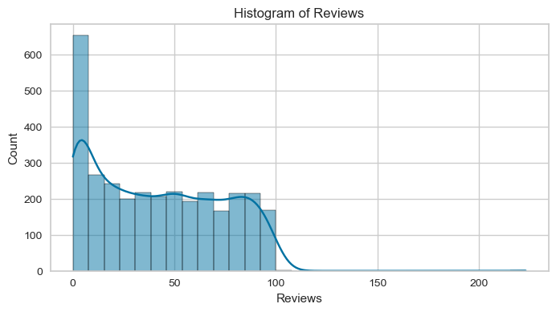

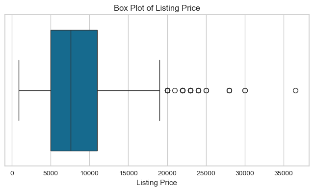

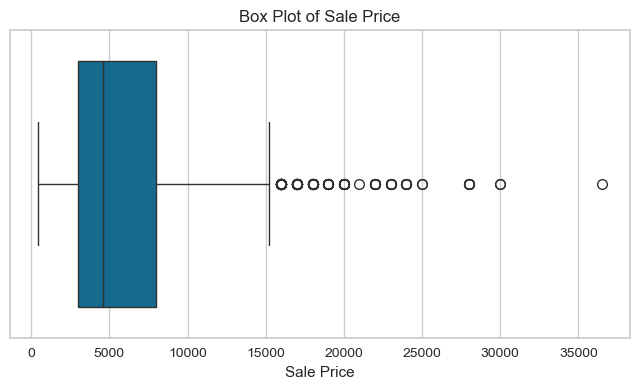

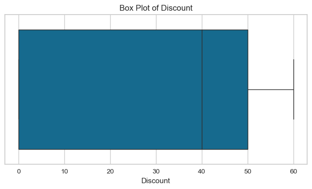

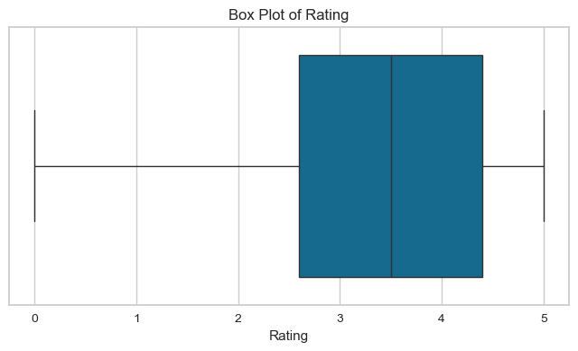

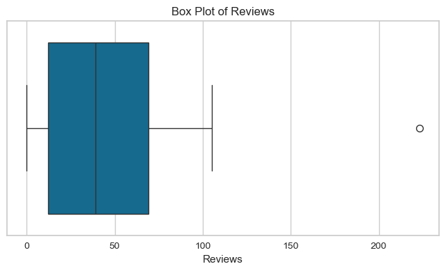

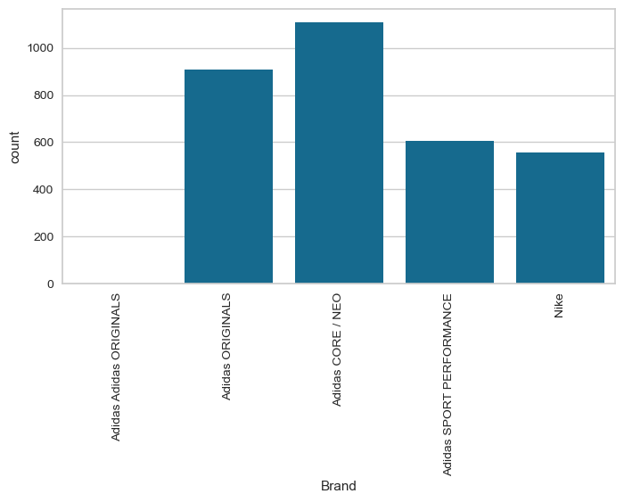

```python
# Histogram for numerical columns
numerical_columns = data.select_dtypes(include=['float64', 'int64']).columns
for column in numerical_columns:
    plt.figure(figsize=(8, 4))
    sns.histplot(data[column], kde=True)
    plt.title(f'Histogram of {column}')
    plt.show()

# Box plot for numerical columns
for column in numerical_columns:
    plt.figure(figsize=(8, 4))
    sns.boxplot(x=data[column])
    plt.title(f'Box Plot of {column}')
    plt.show()

# Bar plot for categorical columns
categorical_columns = data.select_dtypes(include=['object']).columns
categorical_columns = [col for col in categorical_columns if col not in ['Product Name', 'Product ID']]
for column in categorical_columns:
    plt.figure(figsize=(8, 4))

    sns.countplot(x=data[column])
    plt.xticks(rotation=90)
```

#### Observations:

1. From the plots, it can be seen that Sales price and listing price have significant outliers.
2. Maximum number of records are for the brand, Adidas CORE/NEO

#### Q2 E Perform bivariate and multivariate analysis and share your insights.

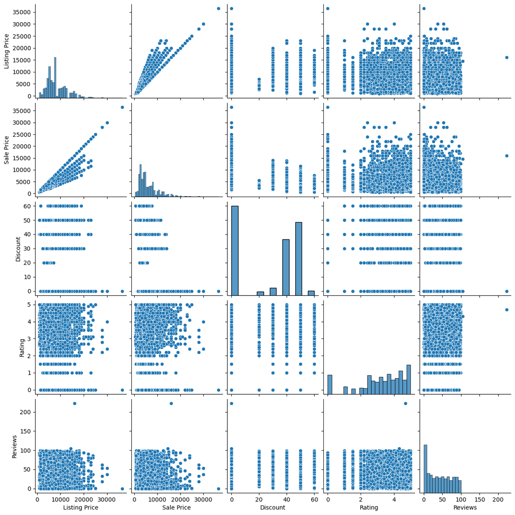

```python
plt.figure(figsize=(12, 12))
sns.pairplot(data[numerical_columns])
plt.show()
```

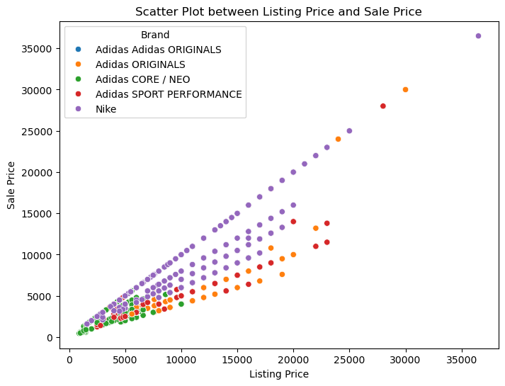

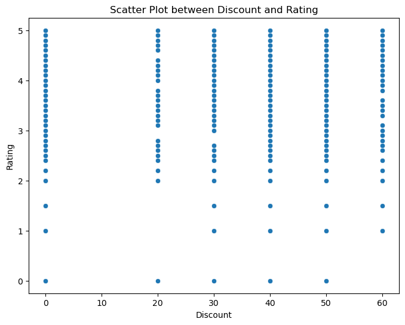

```python
plt.figure(figsize=(8, 6))
sns.scatterplot(x='Listing Price', y='Sale Price',  hue = 'Brand',data=data)
plt.title('Scatter Plot between Listing Price and Sale Price')
plt.show()

# Scatter plot between Discount and Rating
plt.figure(figsize=(8, 6))
sns.scatterplot(x='Discount', y='Rating',data=data)
plt.title('Scatter Plot between Discount and Rating')
plt.show()
```

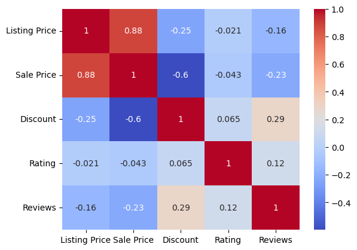

```python
sns.heatmap(data[numerical_columns].corr(),annot=True,cmap='coolwarm')
```

#### Observations:

From the plots, we can see that, Listing and sale price are highly correlated and Sale price and discount are also correlated.

### Data Preparation

#### Q3 A Scale all the numeric variables using suitable technique

```python
data_scaled = data[numerical_columns].apply(zscore)

data_scaled.head()
```

|  | Listing Price | Sale Price | Discount | Rating | Reviews |
| --- | --- | --- | --- | --- | --- |
| 0 | 1.542811 | 0.350983 | 0.995182 | 1.100470 | -0.016882 |
| 1 | -0.153394 | -0.531688 | 0.995182 | 0.023945 | -0.558817 |
| 2 | -1.666226 | -1.295079 | 0.550517 | -0.478433 | -0.144396 |
| 3 | -0.290924 | -0.603256 | 0.995182 | 0.598092 | -0.208153 |
| 4 | -0.061707 | -0.483976 | 0.995182 | 0.167482 | 0.971353 |

```python
data_scaled = data_scaled.applymap(lambda x: np.nan if x < 0 else x)

# Handle NaN values by imputing with the median of the respective column
for column in data_scaled.columns:
    median_value = data_scaled[column].median()
    data_scaled[column] = data_scaled[column].apply(lambda x: median_value if pd.isna(x) else x)
```

```python
data_scaled
```

|  | Listing Price | Sale Price | Discount | Rating | Reviews |
| --- | --- | --- | --- | --- | --- |
| 0 | 1.542811 | 0.350983 | 0.995182 | 1.100470 | 0.907596 |
| 1 | 0.855161 | 0.708822 | 0.995182 | 0.023945 | 0.907596 |
| 2 | 0.855161 | 0.708822 | 0.550517 | 0.669860 | 0.907596 |
| 3 | 0.855161 | 0.708822 | 0.995182 | 0.598092 | 0.907596 |
| 4 | 0.855161 | 0.708822 | 0.995182 | 0.167482 | 0.971353 |
| ... | ... | ... | ... | ... | ... |
| 3260 | 0.855161 | 0.111469 | 0.995182 | 0.669860 | 0.907596 |
| 3262 | 1.312678 | 1.900667 | 0.995182 | 0.669860 | 0.907596 |
| 3263 | 1.771112 | 1.614872 | 0.995182 | 1.244007 | 0.907596 |
| 3266 | 2.000329 | 2.616346 | 0.995182 | 0.526323 | 0.907596 |
| 3267 | 0.166593 | 0.064234 | 0.995182 | 0.669860 | 0.907596 |

3180 rows × 5 columns

```python
data_scaled.head()
```

|  | Listing Price | Sale Price | Discount | Rating | Reviews |
| --- | --- | --- | --- | --- | --- |
| 0 | 1.542811 | 0.350983 | 0.995182 | 1.100470 | 0.907596 |
| 1 | 0.855161 | 0.708822 | 0.995182 | 0.023945 | 0.907596 |
| 2 | 0.855161 | 0.708822 | 0.550517 | 0.669860 | 0.907596 |
| 3 | 0.855161 | 0.708822 | 0.995182 | 0.598092 | 0.907596 |
| 4 | 0.855161 | 0.708822 | 0.995182 | 0.167482 | 0.971353 |

```python
columns_to_convert = ['Brand_Adidas CORE / NEO', 'Brand_Adidas ORIGINALS', 'Brand_Adidas SPORT PERFORMANCE', 'Brand_Nike']

# Convert the specified columns to integers
data[columns_to_convert] = data[columns_to_convert].astype(int)

data_scaled = pd.concat([data_scaled, data[columns_to_convert]], axis=1)

data_scaled.head()
```

|  | Listing Price | Sale Price | Discount | Rating | Reviews | Brand_Adidas CORE / NEO | Brand_Adidas ORIGINALS | Brand_Adidas SPORT PERFORMANCE | Brand_Nike |
| --- | --- | --- | --- | --- | --- | --- | --- | --- | --- |
| 0 | 1.542811 | 0.350983 | 0.995182 | 1.100470 | 0.907596 | 0 | 0 | 0 | 0 |
| 1 | 0.855161 | 0.708822 | 0.995182 | 0.023945 | 0.907596 | 0 | 1 | 0 | 0 |
| 2 | 0.855161 | 0.708822 | 0.550517 | 0.669860 | 0.907596 | 1 | 0 | 0 | 0 |
| 3 | 0.855161 | 0.708822 | 0.995182 | 0.598092 | 0.907596 | 1 | 0 | 0 | 0 |
| 4 | 0.855161 | 0.708822 | 0.995182 | 0.167482 | 0.971353 | 0 | 1 | 0 | 0 |

### Clustering

#### Q4 A Apply K-Means clustering for 2 to 10 clusters

```python
clusters = range(2,11)
ss = []
for k in clusters:
    model = KMeans (n_clusters=k,n_init=10, max_iter=300, random_state=1)
    model.fit(data_scaled)
    ss.append(model.inertia_)
```

#### Q4 B Plot a visual and find elbow point.

#### Q4 C Considering the above visual, mention which are the optimal clusters.

```python
from yellowbrick.cluster import KElbowVisualizer, SilhouetteVisualizer
```

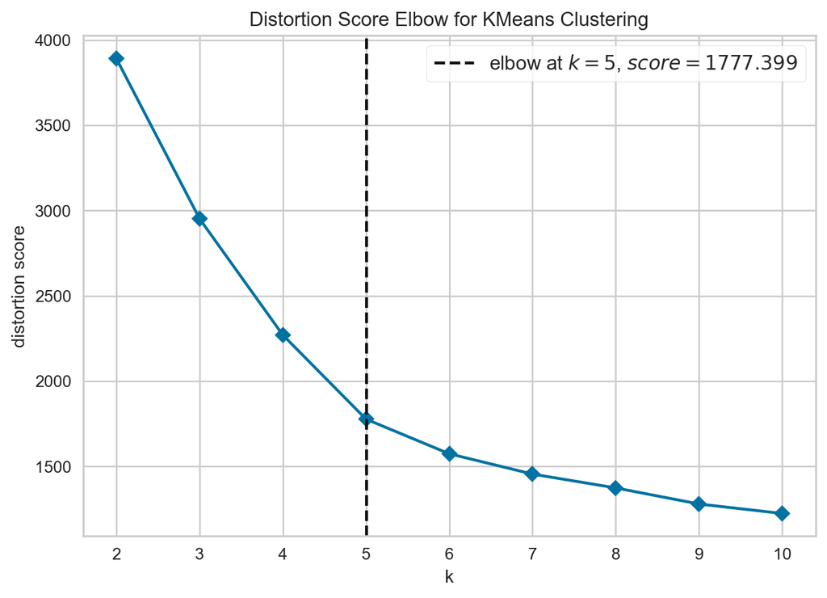

```python
model = KMeans(n_init=10, max_iter=300, random_state=1)

# Using distortion as the metric
plt.figure(dpi=200)
elbow_visualizer = KElbowVisualizer(model, k=(2,11), metric='distortion', timings=False)
elbow_visualizer.fit(data_scaled)
elbow_visualizer.show()
```

###### Finding elbow points using kneed library

```python
from kneed import KneeLocator
```

```
{5}
```

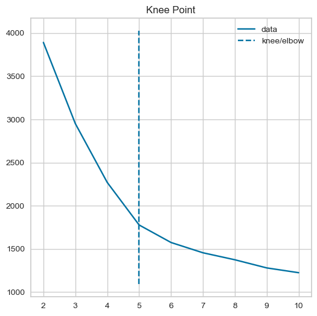

```python
k = KneeLocator(x=range(2,11),y=ss,curve='convex',direction='decreasing',interp_method='polynomial')
print(k.all_elbows)
k.plot_knee()
```

##### Both methods indicate elbow point as 5.

#### Q4 D Calculate silhouette scores of all K clusters 2 to 10.

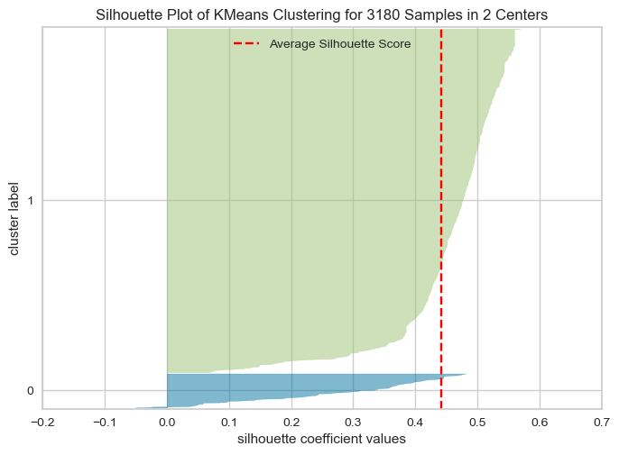

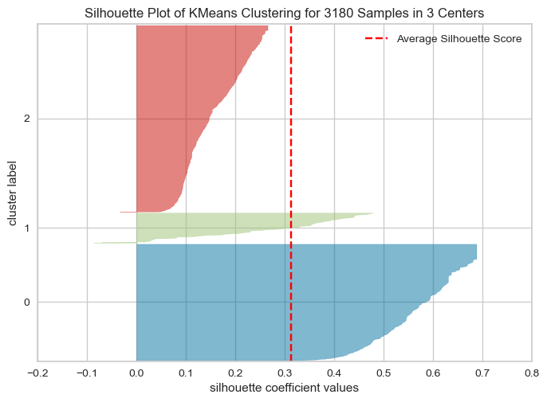

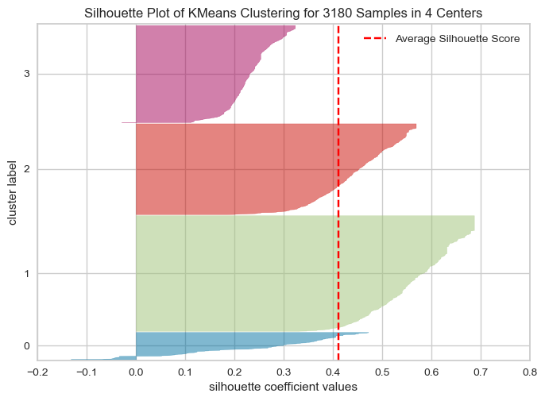

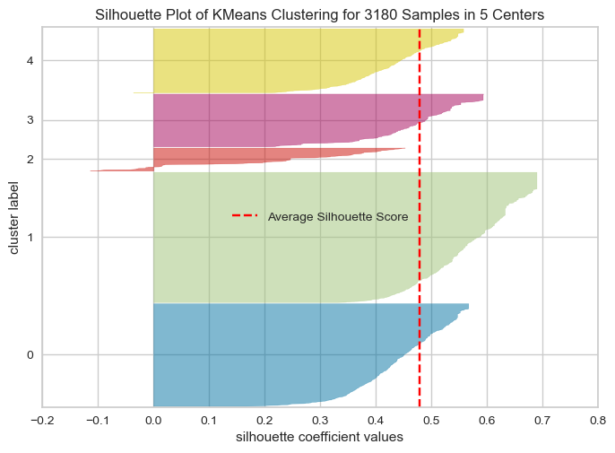

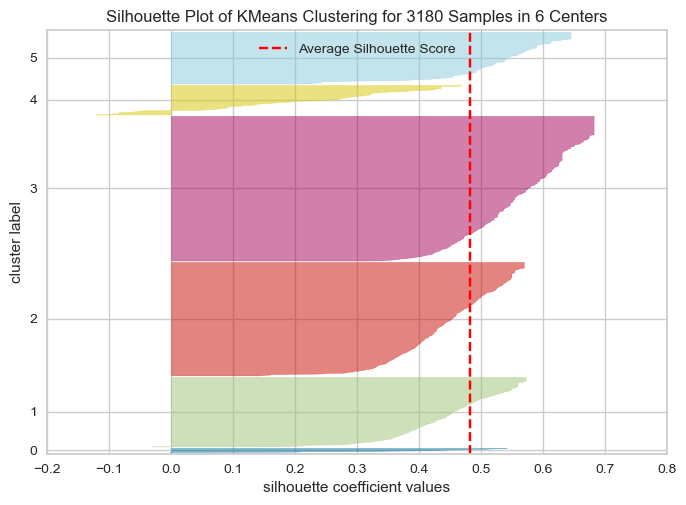

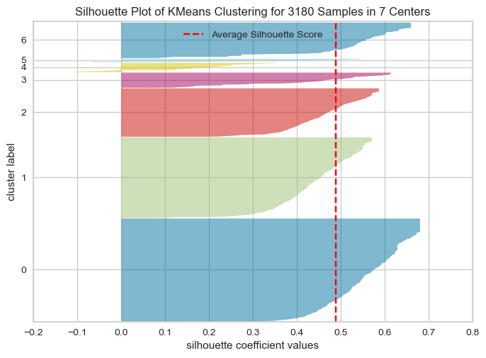

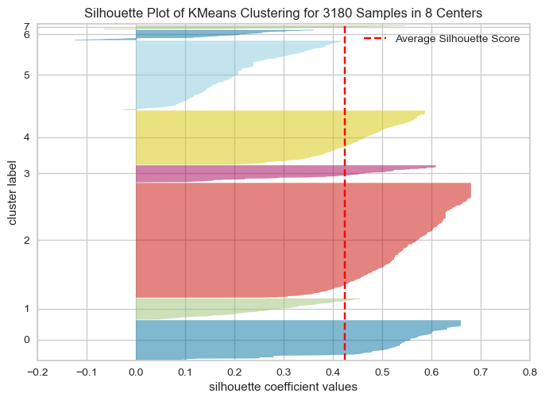

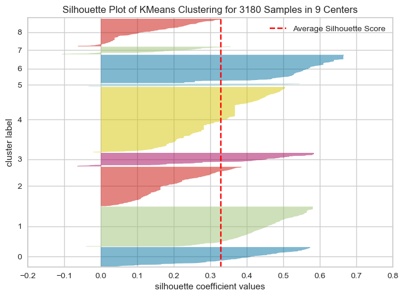

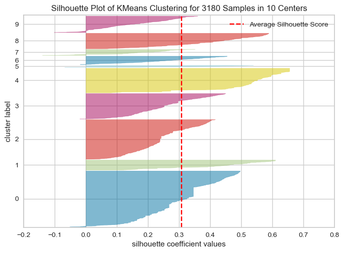

```python
clusters = range(2,11)
for k in clusters:
    model = KMeans(n_clusters=k, n_init=10, max_iter=300, random_state=1)
    silhouette_visualizer = SilhouetteVisualizer(model, colors='yellowbrick')
    silhouette_visualizer.fit(data_scaled)
    silhouette_visualizer.show()
```

#### Q4 E Considering 4.c and 4.d, what is the optimal value of K?

From the elbow point visualizers, optimal K= 5. But the elbow point is not very clear. However from silhoutte scores, it can be seen that K= 5 have good score. Hence we can choose the Optimal value of K=5

#### Q4 F Train a K-means clustering model once again on the optimal number of clusters.

```python
model_optimal = KMeans(n_clusters=5,n_init=10,max_iter=300,random_state=1)
model_optimal.fit(data_scaled)
labels = model_optimal.predict(data_scaled)
```

#### Q4 G Add K-means cluster labels to the original data.

```python
data_scaled_copy = data_scaled.copy(deep=True)


data['cluster']=labels
```

```python
from collections import Counter

# To get the number of datapoints in each cluster
Counter(model_optimal.labels_)
```

```
Counter({1: 1111, 0: 875, 4: 547, 3: 450, 2: 197})
```

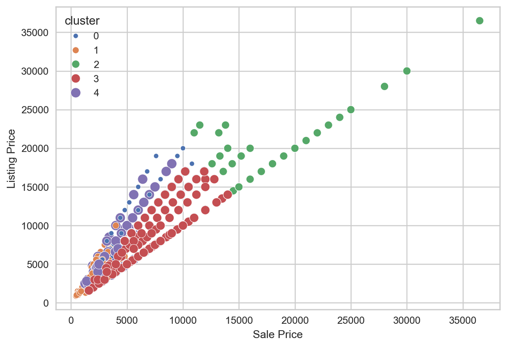

```python
plt.figure(dpi=200)
sns.scatterplot(data=data,x='Sale Price', y='Listing Price',hue='cluster',size='cluster',palette='deep',legend='full')
```

```python
data_for_pred = data.drop(['Product Name','Product ID','cluster'],axis=1)
```

```python
data_for_pred.head()
```

|  | Listing Price | Sale Price | Discount | Rating | Reviews | Brand_Adidas CORE / NEO | Brand_Adidas ORIGINALS | Brand_Adidas SPORT PERFORMANCE | Brand_Nike |
| --- | --- | --- | --- | --- | --- | --- | --- | --- | --- |
| 0 | 14999 | 7499 | 50 | 4.8 | 41 | 0 | 0 | 0 | 0 |
| 1 | 7599 | 3799 | 50 | 3.3 | 24 | 0 | 1 | 0 | 0 |
| 2 | 999 | 599 | 40 | 2.6 | 37 | 1 | 0 | 0 | 0 |
| 3 | 6999 | 3499 | 50 | 4.1 | 35 | 1 | 0 | 0 | 0 |
| 4 | 7999 | 3999 | 50 | 3.5 | 72 | 0 | 1 | 0 | 0 |

```python
new = {'Listing Price': 23000, 'Sale Price': 17000, 'Discount': 0, 'Rating': 4,'Reviews':41,
       'Brand_Adidas CORE / NEO': 0, 'Brand_Adidas ORIGINALS': 0,
       'Brand_Adidas SPORT PERFORMANCE': 1, 'Brand_Nike': 0}

# Assuming data_for_pred is your DataFrame for prediction
# Convert new data point to DataFrame
new_df = pd.DataFrame([new])

# Append new data point using pd.concat
new_X = pd.concat([data_for_pred, new_df], ignore_index=True)

# Scaling
new_scaled = new_X.apply(zscore)
new_scaled = new_scaled.applymap(lambda x: np.nan if x < 0 else x)
for column in new_scaled.columns:
    median_value = new_scaled[column].median()
    new_scaled[column] = new_scaled[column].apply(lambda x: median_value if pd.isna(x) else x)

# Predicting cluster using optimized model

cluster_predicted = model_optimal.predict([new_scaled.iloc[new_scaled.shape[0]-1]])

# Result

print('The predicted cluster for the new data point is : ',cluster_predicted)
```

```
The predicted cluster for the new data point is :  [2]
```

#### Q4 H Do cluster profiling and display.

```python
num_col=data.select_dtypes(include=['float64', 'int64','int32']).columns

# Group by Cluster and calculate descriptive statistics
cluster_profile = data[num_col].groupby('cluster').mean()

# Print the cluster profile
print(cluster_profile)
```

```
         Listing Price    Sale Price   Discount    Rating    Reviews  \
cluster
0          9370.314286   6327.800000  31.931429  3.314400  49.517714
1          4951.835284   3116.212421  36.300630  3.412331  48.205221
2         18413.137056  17042.741117   5.025381  3.175127  27.329949
3         10044.111111   8734.275556   0.000000  2.775333   6.742222
4          8126.422303   5267.716636  33.948812  3.331444  48.925046

         Brand_Adidas CORE / NEO  Brand_Adidas ORIGINALS  \
cluster
0                            0.0                1.000000
1                            1.0                0.000000
2                            0.0                0.162437
3                            0.0                0.000000
4                            0.0                0.000000

         Brand_Adidas SPORT PERFORMANCE  Brand_Nike
cluster
0                              0.000000    0.000000
1                              0.000000    0.000000
2                              0.304569    0.532995
3                              0.000000    1.000000
4                              0.998172    0.000000
```

#### Q4 I Share your insights on the clusters which are built. Here try to explain what each cluster is saying.

#### Q4 J Considering the cluster profiles, give any 2-business recommendation which will help the business.

Based on the cluster profile, we can derive the following insights for each cluster:

#### Cluster 0:

- **Listing Price**: 9370
- **Sale Price**: 6327
- **Discount**: 31.93%
- **Rating**: 3.31
- **Reviews**: 49.52
- **Brand**: Predominantly `Adidas ORIGINALS`

**Insights**: Cluster 0 consists mainly of products from the `Adidas ORIGINALS` brand with a moderate listing price and discount. This cluster has a good number of reviews and ratings indicating moderately popular products.

#### Cluster 1:

- **Listing Price**: 4951
- **Sale Price**: 3116
- **Discount**: 36.30%
- **Rating**: 3.41
- **Reviews**: 48.21
- **Brand**: Predominantly `Adidas CORE / NEO`

**Insights**: Cluster 1 includes products mostly from the `Adidas CORE / NEO` brand with relatively lower listing prices and higher discounts. This cluster also has a good number of reviews and ratings, suggesting these products are quite popular among cost-sensitive customers.

#### Cluster 2:

- **Listing Price**: 18413
- **Sale Price**: 17042
- **Discount**: 5.03%
- **Rating**: 3.18
- **Reviews**: 27.33
- **Brand**: Mixed with `Nike` and some `Adidas SPORT PERFORMANCE`

**Insights**: Cluster 2 is composed of high-end products with high listing and sale prices. These products come from mixed brands, including `Nike` and `Adidas SPORT PERFORMANCE`. The discount rate is very low, and the number of reviews is comparatively lower, indicating these are premium products with a niche customer base.

#### Cluster 3:

- **Listing Price**: 10044
- **Sale Price**: 8734
- **Discount**: 0%
- **Rating**: 2.77
- **Reviews**: 6.74
- **Brand**: Predominantly `Nike`

**Insights**: Cluster 3 contains products primarily from the `Nike` brand with moderate listing prices but zero discounts. These products have low ratings and very few reviews, indicating they are less popular among customers.

#### Cluster 4:

- **Listing Price**: 8126
- **Sale Price**: 5267
- **Discount**: 33.95%
- **Rating**: 3.33
- **Reviews**: 48.93
- **Brand**: Predominantly `Adidas SPORT PERFORMANCE`

**Insights**: Cluster 4 is characterized by products from the `Adidas SPORT PERFORMANCE` brand with moderate listing prices and considerable discounts. This cluster has a healthy number of reviews and ratings, signifying these products are popular among customers looking for sports performance gear at discounted prices.

### Business Recommendations

Based on the cluster profiles, here are two business recommendations:

#### 1. **Tailored Marketing Strategies**:

- **Premium Segment (Cluster 2)**: Focus marketing efforts on highlighting the exclusivity and premium quality of high-end products from `Nike` and `Adidas SPORT PERFORMANCE`. Use targeted advertising to reach a niche, high-income customer base.
- **Discount-Oriented Segment (Clusters 1 and 4)**: Promote these clusters to cost-sensitive customers who are looking for quality products at a discount. Emphasize the value-for-money aspect in marketing campaigns for products from `Adidas CORE / NEO` and `Adidas SPORT PERFORMANCE`.

#### 2. **Product Improvement and Inventory Management**:

- **Underperforming Products (Cluster 3)**: Investigate why `Nike` products in this cluster have low ratings and few reviews. Consider product improvements or re-evaluate pricing strategies to boost their attractiveness. These products may require better visibility or enhancements to meet customer expectations.
- **Popular Products (Clusters 0 and 1)**: Ensure adequate inventory for products in these clusters to meet demand, as they have moderate prices, good discounts, and high customer engagement. Consider expanding the product range or introducing similar products to capitalize on their popularity.

Implementing these recommendations can help the business optimize its product offerings, improve customer satisfaction, and increase overall sales.